# Plausibility bounds for the SD of bounded questionnaire scores

An analytic method, its validation, and the functions in the strait package

Author

Affiliation

Ian Hussey

University of Bern

# The question

A paper reports a mean of 25 and an SD of 8 on the BDI-II (0–63) for $N = 50$ people. Is that SD plausible?

*Hard* bounds answer a narrower question: is the SD *possible*? The largest possible SD comes from putting as many scores as possible at the two scale limits (Muilwijk, 1966; Bhatia & Davis, 2000). The smallest comes from putting all scores on the two integers next to the mean. For this example the hard range is about 0 to 31. Nearly every SD a real paper reports passes.

*Plausibility* bounds ask what a realistic data-generating process would produce: the range of sample SDs you would see at this mean and $N$ if the scores came from the kind of distribution that questionnaire data actually follow. An SD far outside that range is not impossible, but it is surprising enough to warrant a closer look.

The previous approach was simulation. Fit beta-binomial regressions to a corpus of raw BDI-II data, predict the dispersion at each mean, sample from that beta-binomial at each $N$, and take the 1% and 0.1% quantiles of the sample SD. This document replaces the simulation with analytic and exact calculations, and validates them.

# The model

Scores are $X = \text{score} - L \in \{0, \dots, m\}$ with $m = U - L$ ($m = 63$ for the BDI-II). They are modelled as

$$X \sim \text{BetaBinomial}(m, \alpha, \beta), \qquad
\mu = \frac{\alpha}{\alpha + \beta}, \qquad
\rho = \frac{1}{\alpha + \beta + 1},$$

so that

$$E[X] = m\mu, \qquad \sigma^2 = m\mu(1 - \mu)\,[1 + (m - 1)\rho].$$

$\rho$ is the intra-class correlation of the $m$ Bernoulli trials behind the score. $\rho = 0$ is the binomial, the least dispersed member of the family. As $\rho \to 1$, all mass moves to the two endpoints. All population moments are computed exactly from the pmf, $\log p(x) = \log\binom{m}{x} + \log B(x + \alpha, m - x + \beta) - \log B(\alpha, \beta)$, rather than from closed forms:

```r
bb_cumulants(m = 63, mu = 25 / 63, rho = 0.052)
```

```
#> # A tibble: 1 x 8
#>    mean    k2    k3    k4     k5     k6    g1     g2
#>   <dbl> <dbl> <dbl> <dbl>  <dbl>  <dbl> <dbl>  <dbl>
#> 1    25  63.7  93.7 -977. -9136. 67824. 0.184 -0.241
```

## Estimating the dispersion from summary statistics

Given a reported $(L, U, M, SD)$, the method of moments gives

$$\hat\mu = \frac{M - L}{m}, \qquad
\hat\rho = \frac{1}{m - 1}\left[\frac{SD^2}{m\hat\mu(1 - \hat\mu)} - 1\right].$$

$\hat\rho$ is linear in $S^2$, so it is unbiased for $\rho$ given $\mu$, and its sampling variance is $\operatorname{Var}(S^2)/[m(m - 1)\mu(1 - \mu)]^2$. Negative $\hat\rho$ are kept: truncating them would bias a corpus average upward.

```r
rho_from_summary(L = 0, U = 63, M = 25, SD = 8, N = 50)
```

```
#> # A tibble: 1 x 3
#>   mu_hat rho_hat  var_rho
#>    <dbl>   <dbl>    <dbl>
#> 1  0.397  0.0523 0.000169
```

Using a paper’s own SD to set $\rho$ and then checking that same SD is circular, and the functions allow it only for illustration. In practice $\rho$ comes from a corpus (see Estimating ρ from a corpus).

# The sampling distribution of the sample SD

## Two moments

For any iid process with a finite fourth moment, the unbiased sample variance satisfies

$$E[S^2] = \sigma^2, \qquad
\operatorname{Var}(S^2) = \sigma^4\left[\frac{2}{N - 1} + \frac{\gamma_2}{N}\right],
\qquad \gamma_2 = \frac{\mu_4}{\sigma^4} - 3 .$$

The **two-moment approximation** (Box, 1954; Satterthwaite, 1946) matches these with a scaled chi-square:

$$S^2 \approx \sigma^2\,\frac{\chi^2_\nu}{\nu}, \qquad
\nu = \frac{2}{2/(N - 1) + \gamma_2/N}, \qquad
q_p(S) = \sigma\sqrt{\chi^2_{\nu,p}/\nu}.$$

With normal data, $\gamma_2 = 0$ and $\nu = N - 1$, the textbook result. Because $\gamma_2 \ge -2$ for any distribution, the denominator is always positive. The approximation reproduces the reference table exactly:

```r
ref <- sd_plausibility(0, 63, M = 25, N = c(20, 50, 100, 500),
                       p = c(0.01, 0.001), sd = 8)
ref[, c("N", "p", "rho", "sigma", "hard_min", "hard_max", "lower", "upper")]
```

```
#> # A tibble: 8 x 8
#>       N     p    rho sigma hard_min hard_max lower upper
#>   <dbl> <dbl>  <dbl> <dbl>    <dbl>    <dbl> <dbl> <dbl>
#> 1    20 0.01  0.0523  8.00        0     31.4  5.24 10.9
#> 2    20 0.001 0.0523  8.00        0     31.4  4.47 11.9
#> 3    50 0.01  0.0523  8.00        0     31.0  6.26  9.78
#> 4    50 0.001 0.0523  8.00        0     31.0  5.74 10.4
#> 5   100 0.01  0.0523  8.00        0     30.8  6.77  9.25
#> 6   100 0.001 0.0523  8.00        0     30.8  6.39  9.68
#> 7   500 0.01  0.0523  8.00        0     30.8  7.45  8.55
#> 8   500 0.001 0.0523  8.00        0     30.8  7.27  8.74
```

## Three moments

The two-moment approximation gets the skewness of $S^2$ right only for normal-like data. The third cumulant of $S^2$, in terms of the population cumulants $\kappa_2, \dots, \kappa_6$, is

$$\kappa_3(S^2) = \frac{\kappa_6}{N^2} + \frac{12\kappa_2\kappa_4}{N(N - 1)}
+ \frac{4(N - 2)\kappa_3^2}{N(N - 1)^2} + \frac{8\kappa_2^3}{(N - 1)^2}.$$

For normal data this is $8\sigma^6/(N - 1)^2$, the third cumulant of $\sigma^2\chi^2_{N-1}/(N-1)$. The test suite checks the formula against the exact distribution below, and it agrees to machine precision. Two refinements use it:

- **Cornish–Fisher** (`method = "cf"`): $q_p(S^2) \approx \kappa_1 + \sqrt{\kappa_2}\,[z_p + \tfrac{\gamma}{6}(z_p^2 - 1)]$, with $\gamma = \kappa_3/\kappa_2^{3/2}$ the skewness of $S^2$. The CDF is obtained by solving the quadratic in $z$, which is needed for the mixture below.
- **Three-moment chi-square** (`method = "chisq3"`): $S^2 \approx a + b\chi^2_\nu$ with $b = \kappa_3/(4\kappa_2)$, $\nu = 8\kappa_2^3/\kappa_3^2$ and $a = \kappa_1 - b\nu$ (a Pearson type III fit). It keeps the chi-square shape, so it behaves better than Cornish–Fisher in the far tails.

## Exact, by dynamic programming

Because $X$ is a bounded integer, the exact distribution of $S^2 = [\sum X^2 - (\sum X)^2/N]/(N - 1)$ follows from the joint distribution of $(T, Q) = (\sum X, \sum X^2)$. That joint distribution builds up one observation at a time:

$$P_{n+1}(t, q) = \sum_{x=0}^{m} p(x)\, P_n(t - x,\ q - x^2).$$

For each sum $t$, $q$ lies between the most even split of $t$ over $n$ values and the most extreme one, so the state is stored as one vector per $t$ over that range (`s2_exact()`). The cost grows roughly as $N^2 m^3$. On a 0–63 scale the method is practical up to about $N = 25$: $N = 20$ takes under a minute. Values and sums with probability below $10^{-17}$ are pruned, and the discarded mass is reported (below $10^{-14}$ throughout the validation). The exact method is the ground truth for small $N$, and it also gives the distribution *conditional on the sample mean*, which matters below.

# Heterogeneity: mixing over ρ

A corpus meta-regression predicts a mean $\rho$ at each $\mu$ and a between-study SD $\tau$. The plausibility bound is then a quantile of the **mixture** over $\rho \sim N(\rho, \tau^2)$ truncated to $[0, 1)$:

$$F_S(s) = \int F_S(s \mid \rho)\, \mathrm{d}G(\rho), \qquad
\text{bound} = F_S^{-1}(p).$$

`sd_plausibility()` represents $G$ by $K$ equal-weight quantile nodes of the truncated normal. It averages the per-node CDFs and inverts the average. Averaging per-node quantiles would be wrong, because the quantile of a mixture is not the mixture of quantiles.

```r
sd_plausibility(0, 63, M = 25, N = 50, p = 0.001, rho = 0.052,
                tau = c(0, 0.01, 0.02, 0.04))[, c("tau", "lower", "upper")]
```

```
#> # A tibble: 4 x 3
#>     tau lower upper
#>   <dbl> <dbl> <dbl>
#> 1  0     5.72  10.4
#> 2  0.01  5.24  11.0
#> 3  0.02  4.03  12.1
#> 4  0.04  3.42  14.1
```

# Hard bounds

The plausibility bounds are reported next to the hard bounds, and clipped to them:

- **Ceiling:** the sharp mean-conditional maximum for integer data, `sd_max_structure_s()`: as many scores as possible at the two limits, with at most one in between (Mestdagh et al., 2018). This is never above the Bhatia–Davis bound $\sqrt{N/(N-1)\,(M - L)(U - M)}$.
- **Floor:** the minimum variance over integer vectors of length $N$ with mean $M$. It puts every score on the two integers next to $M$: with $f$ the fractional part of $M - L$, $SD_{\min} = \sqrt{N/(N - 1)}\sqrt{f(1 - f)}$ (`sd_min_integer()`). With `digits`, the floor is the minimum over every integer sum whose mean rounds to the reported $M$. When no integer sample has mean $M$ exactly, the quasi-integer floor is used, which is valid at every real mean.

# Validation

The approximations were compared with ground truth on the grid in the spec: $m = 63$, $\mu \in \{0.1, 0.3, 0.5\}$, $\rho \in \{0.02, 0.05, 0.15\}$, $N \in \{10, 20, 50, 200\}$, at the 1% and 0.1% quantiles in each tail. That is 144 quantiles per method. The ground truth is the exact distribution where $N \le 20$, and Monte Carlo with $10^6$ replicates otherwise. The replicates are sampled as multinomial counts, so the cost does not grow with $N$. The script is `dev/sd-plausibility-bounds/validate.R`.

**Monte Carlo agrees with the exact method** wherever both exist. The median 95% half-width of a Monte Carlo quantile is 0.14%. The largest difference between the two, 2.6%, is one step of discreteness: at $\mu = 0.1$, $N = 10$, the attainable SDs next to the 0.1% quantile are 1.197 and 1.229, and the Monte Carlo quantile landed on the second. Where the ground truth is Monte Carlo ($N \ge 50$), errors below about 1% cannot be resolved.

```r
summ <- do.call(rbind, lapply(c("chisq2", "chisq3", "cf"), function(meth) {
  e <- val[[paste0("rel_", meth)]]
  do.call(rbind, lapply(split(seq_len(nrow(val)), list(val$tail, val$p)),
    function(i) data.frame(
      method = meth, tail = val$tail[i[1]], p = val$p[i[1]],
      over_2pct = sum(abs(e[i]) > 0.02), of = length(i),
      max_abs_error = pct(max(abs(e[i])), 1))))
}))
rownames(summ) <- NULL
knitr::kable(summ)
```

Table 1: Relative error of each approximation against ground truth: the share of the 144 quantiles off by more than 2%, and the largest error, by tail and quantile.

| method | tail | p | over_2pct | of | max_abs_error |
| --- | --- | --- | --- | --- | --- |
| chisq2 | lower | 0.001 | 15 | 36 | 29.0% |
| chisq2 | upper | 0.001 | 8 | 36 | 4.5% |
| chisq2 | lower | 0.010 | 12 | 36 | 16.7% |
| chisq2 | upper | 0.010 | 1 | 36 | 2.1% |
| chisq3 | lower | 0.001 | 16 | 36 | 100.0% |
| chisq3 | upper | 0.001 | 0 | 36 | 1.7% |
| chisq3 | lower | 0.010 | 10 | 36 | 23.6% |
| chisq3 | upper | 0.010 | 0 | 36 | 0.3% |
| cf | lower | 0.001 | 17 | 36 | 63.6% |
| cf | upper | 0.001 | 0 | 36 | 1.7% |
| cf | lower | 0.010 | 10 | 36 | 20.5% |
| cf | upper | 0.010 | 0 | 36 | 1.0% |

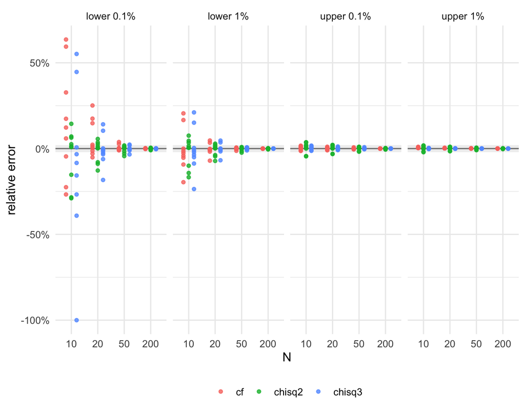

Figure 1: Relative error of each approximation against ground truth, by N, tail and quantile. Each point is one (μ, ρ) cell; the band marks ±2%. Truth is exact for N ≤ 20 and Monte Carlo (10^6 replicates) above.

```r
long <- do.call(rbind, lapply(c("chisq2", "chisq3", "cf"), function(meth) {
  data.frame(val[c("mu", "rho", "N", "tail", "p")], method = meth,
             err = val[[paste0("rel_", meth)]])
}))
long$quantile <- paste0(long$tail, " ", long$p * 100, "%")
ggplot(long, aes(factor(N), err, colour = method)) +
  annotate("rect", xmin = -Inf, xmax = Inf, ymin = -0.02, ymax = 0.02,
           alpha = 0.1) +
  geom_hline(yintercept = 0, colour = "grey50") +
  geom_point(position = position_dodge(width = 0.6), size = 1.3, alpha = 0.8) +
  facet_wrap(~quantile, nrow = 1) +
  scale_y_continuous(labels = function(x) paste0(100 * x, "%")) +
  labs(x = "N", y = "relative error", colour = NULL) +
  theme(legend.position = "bottom")
```

```r
worst <- val[abs(val$rel_chisq2) > 0.02,
             c("mu", "rho", "N", "tail", "p", "truth",
               "rel_chisq2", "rel_chisq3", "rel_cf")]
worst <- worst[order(-abs(worst$rel_chisq2)), ]
worst$truth <- round(worst$truth, 2)
for (v in c("rel_chisq2", "rel_chisq3", "rel_cf")) worst[[v]] <- pct(worst[[v]])
rownames(worst) <- NULL
knitr::kable(worst)
```

Table 2: The cells where the default two-moment method is off by more than 2%, with the three-moment and Cornish–Fisher errors for comparison.

| mu | rho | N | tail | p | truth | rel_chisq2 | rel_chisq3 | rel_cf |
| --- | --- | --- | --- | --- | --- | --- | --- | --- |
| 0.1 | 0.05 | 10 | lower | 0.001 | 1.48 | -29.0% | 55.1% | 63.6% |
| 0.1 | 0.15 | 10 | lower | 0.001 | 1.25 | -28.4% | -100.0% | 32.7% |
| 0.1 | 0.05 | 10 | lower | 0.010 | 2.00 | -16.7% | 21.1% | 20.5% |
| 0.1 | 0.02 | 10 | lower | 0.001 | 1.20 | -15.3% | 44.6% | 59.4% |
| 0.5 | 0.15 | 10 | lower | 0.001 | 5.01 | 14.4% | -26.7% | -22.5% |
| 0.1 | 0.15 | 10 | lower | 0.010 | 2.07 | -14.2% | -23.6% | -19.6% |
| 0.1 | 0.05 | 20 | lower | 0.001 | 2.24 | -12.8% | 14.1% | 25.1% |
| 0.1 | 0.02 | 10 | lower | 0.010 | 1.64 | -10.0% | 15.1% | 16.6% |
| 0.1 | 0.15 | 20 | lower | 0.001 | 2.46 | -8.9% | -18.3% | 14.8% |
| 0.1 | 0.02 | 20 | lower | 0.001 | 1.81 | -8.0% | 10.4% | 17.5% |
| 0.5 | 0.15 | 10 | lower | 0.010 | 6.67 | 7.5% | -5.0% | -5.4% |
| 0.1 | 0.05 | 20 | lower | 0.010 | 2.72 | -7.2% | 4.7% | 4.7% |
| 0.3 | 0.15 | 10 | lower | 0.001 | 4.21 | 7.1% | -39.1% | -26.7% |
| 0.5 | 0.05 | 10 | lower | 0.001 | 2.96 | 6.3% | -15.7% | -4.6% |
| 0.5 | 0.15 | 20 | lower | 0.001 | 7.37 | 5.6% | -3.4% | -3.0% |
| 0.1 | 0.02 | 20 | lower | 0.010 | 2.16 | -4.5% | 3.6% | 3.4% |
| 0.1 | 0.05 | 10 | upper | 0.001 | 10.10 | -4.5% | -1.1% | -1.1% |
| 0.3 | 0.15 | 10 | lower | 0.010 | 5.67 | 4.5% | -8.7% | -9.3% |
| 0.1 | 0.05 | 50 | lower | 0.001 | 3.06 | -4.4% | 2.3% | 3.8% |
| 0.1 | 0.02 | 10 | upper | 0.001 | 7.00 | -4.4% | -1.3% | -1.4% |
| 0.1 | 0.15 | 20 | lower | 0.010 | 3.35 | -3.8% | -6.8% | -7.0% |
| 0.5 | 0.15 | 10 | upper | 0.001 | 19.99 | 3.7% | 1.0% | 0.9% |
| 0.3 | 0.15 | 20 | lower | 0.001 | 6.29 | 3.6% | -6.1% | -5.1% |
| 0.3 | 0.15 | 10 | upper | 0.001 | 19.36 | 3.6% | 1.4% | 1.3% |
| 0.5 | 0.05 | 10 | lower | 0.010 | 3.98 | 3.5% | -3.6% | -4.2% |
| 0.1 | 0.05 | 20 | upper | 0.001 | 8.42 | -3.2% | -0.7% | -0.8% |
| 0.1 | 0.02 | 20 | upper | 0.001 | 5.89 | -3.1% | -0.9% | -1.0% |
| 0.1 | 0.02 | 50 | lower | 0.001 | 2.40 | -2.9% | 1.8% | 2.7% |
| 0.5 | 0.15 | 20 | lower | 0.010 | 8.64 | 2.9% | -0.8% | -0.8% |
| 0.5 | 0.05 | 20 | lower | 0.001 | 4.41 | 2.6% | -2.5% | -1.3% |
| 0.5 | 0.02 | 10 | lower | 0.001 | 2.16 | 2.6% | -8.4% | 5.9% |
| 0.1 | 0.05 | 50 | lower | 0.010 | 3.43 | -2.4% | 0.7% | 0.6% |
| 0.3 | 0.15 | 20 | lower | 0.010 | 7.47 | 2.2% | -1.7% | -1.8% |
| 0.1 | 0.05 | 10 | upper | 0.010 | 8.47 | -2.1% | -0.1% | 1.0% |
| 0.3 | 0.15 | 20 | upper | 0.001 | 17.01 | 2.1% | 0.7% | 0.6% |
| 0.5 | 0.15 | 20 | upper | 0.001 | 17.75 | 2.1% | 0.4% | 0.4% |

Three results stand out.

**The two-moment method is reliable at large N and in the upper tail.** All 36 of its quantiles at $N = 200$ are within 2% of the truth. In the upper tail its largest error at any $N$ is 4.5%. Its failures are concentrated where the plan expected them: small $N$, extreme tails, and specifically the **lower** tail of a **skewed** score distribution. At $\mu = 0.1$, $N = 10$, it puts the 0.1% lower bound 29% too low.

**The moment refinements fix the upper tail but not the lower one.** The three-moment chi-square and Cornish–Fisher bring every upper-tail quantile within 2%. In the lower tail at $N \le 20$ they are no better than the two-moment method, and in several cells worse. The three-moment fit returns 0 in one cell because its fitted shift is negative, and Cornish–Fisher overshoots by up to 64%. This is not a matter of adding another cumulant. At small $N$ the lower tail of $S$ is lumpy (a few attainable values carry all the mass) and bounded below, which no smooth moment-matched curve represents well.

**For $N \le 20$, the exact method is the answer.** It takes seconds at $N = 10$ and about a minute at $N = 20$ on a 0–63 scale, and it has no approximation error to validate.

# Review of the plan

The plan is sound: a two-moment approximation with exact moments from the pmf, a mixture over $\rho$ done on the CDF scale, and exact small-$N$ ground truth. Working it through raised six points. Two of them change results.

## 1. Condition on the reported mean

**This is the most consequential point.** A reported SD comes with a reported mean. The bounds above describe samples of size $N$ *in general*, whose means scatter around $m\mu$. For a skewed distribution, $S^2$ and $\bar X$ are correlated: exactly, $\operatorname{Cov}(\bar X, S^2) = \kappa_3/N$. Samples whose mean happens to land at $M$ have a narrower SD distribution than samples in general. The question a forensic check asks is the conditional one: *given that this sample’s mean is $M$*, how surprising is its SD?

Removing the part of $\operatorname{Var}(S^2)$ explained by $\bar X$ gives, to leading order,

$$\operatorname{Var}(S^2 \mid \bar X = \mu) \approx
\operatorname{Var}(S^2) - \frac{\kappa_3^2}{N\sigma^2}
= \sigma^4\left[\frac{2}{N - 1} + \frac{\gamma_2 - \gamma_1^2}{N}\right],$$

which is the unconditional formula with $\gamma_2$ replaced by $\gamma_2 - \gamma_1^2$. Pearson’s inequality ($\gamma_2 \ge \gamma_1^2 - 2$) keeps it positive. The two-moment method uses this with `condition_on_mean = TRUE`. The exact method conditions directly, on the sums whose mean rounds to the reported $M$.

The exact distribution shows how large the effect is. Let the shift be the relative change in a bound when conditioning on the mean. At $\mu = 0.5$ the score distribution is symmetric, $\gamma_1 = 0$, and the leading-order correction vanishes. The exact shift is still up to 3%, a second-order effect at $N \le 20$. At $\mu = 0.3$ the shift is up to 13%. At $\mu = 0.1$, the regime of depression scales in community samples, it is up to 150%. For $\rho = 0.15$ and $N = 10$ the conditional 0.1% lower bound is 3.13 against 1.25 unconditionally, and the conditional upper bound is 14.1 against 16.8. Measured against the conditional truth, the unconditional two-moment bounds are off by up to 71%.

The conditional two-moment correction recovers most of this: its largest error against the exact conditional distribution is 22%. What remains is the small-$N$ lower-tail problem from the validation. The conditional correction has only been checked against exact results up to $N = 20$, where exact is available anyway. Its error shrinks with $N$ (the correction is exact to leading order as $N \to \infty$), but its accuracy at $N = 50$ is not yet verified.

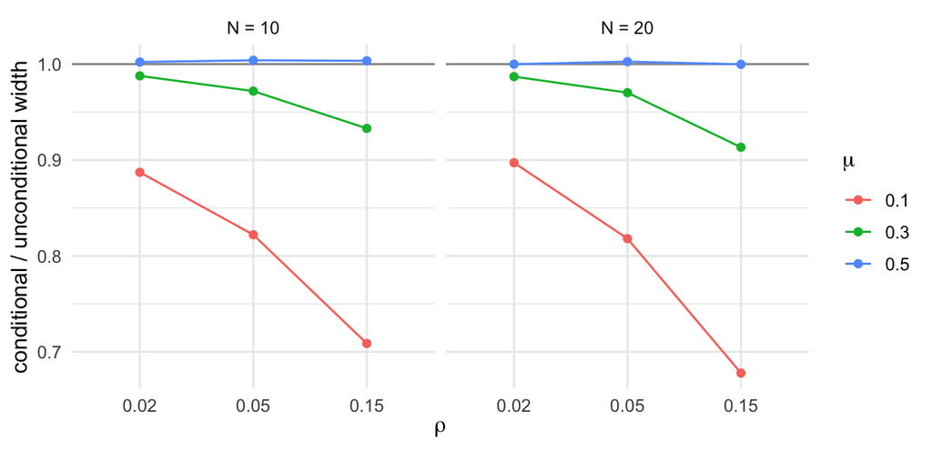

Figure 2: Width of the 0.1%–99.9% plausibility interval for the SD, unconditional and conditional on the sample mean, from the exact distribution (N = 10 and 20). The gap grows with the skew of the score distribution, which is largest at μ = 0.1.

```r
w <- val[val$N <= 20 & val$p == 0.001, ]
wid <- do.call(rbind, lapply(split(w, list(w$mu, w$rho, w$N), drop = TRUE), function(d) {
  lo <- d[d$tail == "lower", ]; hi <- d[d$tail == "upper", ]
  data.frame(mu = lo$mu, rho = lo$rho, N = lo$N,
             unconditional = hi$exact - lo$exact,
             conditional = hi$exact_cond - lo$exact_cond)
}))
wid$ratio <- wid$conditional / wid$unconditional
ggplot(wid, aes(factor(rho), ratio, colour = factor(mu), group = mu)) +
  geom_hline(yintercept = 1, colour = "grey60") +
  geom_line() + geom_point() +
  facet_wrap(~ paste0("N = ", N)) +
  labs(x = expression(rho), y = "conditional / unconditional width",
       colour = expression(mu))
```

## 2. The binomial floor is not a floor for the sample SD

The plan lists as a defect that at small $N$ the lower quantile can fall below $\sigma_{\text{binom}} = \sqrt{m\mu(1 - \mu)}$, “impossible under the model”. It is not impossible. $\sigma_{\text{binom}}$ is a floor on the *population* SD across the family ($\rho \ge 0$). A *sample* SD fluctuates around its population value, and it falls below $\sigma_{\text{binom}}$ often. The exact distribution shows this directly. Across the validation grid at $N = 10$, the exact probability that $S < \sigma_{\text{binom}}$ ranges from 0.01% to 11.5%. Whenever it exceeds $p$, the true lower quantile lies below $\sigma_{\text{binom}}$: this holds for 20 of the 36 exact lower quantiles. Clipping to $\sigma_{\text{binom}}$ would make those lower bounds wrong.

The real constraint is the **hard integer floor** (item 6 of the plan), and that is what the functions clip to. They also report when clipping happened (`clipped`, `note`). With a 64-point scale the floor is rarely binding, because it never exceeds $0.5\sqrt{N/(N-1)}$. It binds on short scales at tiny $N$:

```r
sd_plausibility(0, 2, M = 0.5, N = 4, rho = 0, p = 0.01, method = "chisq2")[
  , c("sigma", "hard_min", "lower", "upper", "clipped")]
```

```
#> # A tibble: 1 x 5
#>   sigma hard_min lower upper clipped
#>   <dbl>    <dbl> <dbl> <dbl> <chr>
#> 1 0.612    0.577 0.577     1 lower+upper
```

## 3. Truncate the ρ distribution, do not clamp it

The starting implementation clamped the $\rho$ nodes with `pmin(pmax(...))`. That puts a point mass at 0 (and near 1) rather than truncating. When $\rho$ is small relative to $\tau$, which is common, a large share of the nodes collapse onto the binomial. The implementation now places the nodes at the quantiles of the truncated normal, as the plan describes.

```r
old_nodes <- function(rho, tau, K = 41)
  pmin(pmax(qnorm((seq_len(K) - 0.5) / K, rho, tau), 0), 1 - 1e-6)
c(clamped_share_at_zero = mean(old_nodes(0.02, 0.03) == 0),
  truncated_share_at_zero = mean(strait:::.rho_nodes(0.02, 0.03, 41) == 0))
```

```
#>   clamped_share_at_zero truncated_share_at_zero
#>               0.2439024               0.0000000
```

## 4. Include the prediction’s own uncertainty

$\tau$ from a meta-regression is the *residual* between-study SD around the fitted curve. The fitted $\rho$ at a given $\mu$ is itself estimated, and its standard error is not part of $\tau$. For a new study, the relevant spread is the prediction interval’s: $\tau_{\text{total}} = \sqrt{\tau^2 + \mathrm{SE}^2}$. `predict()` on a corpus fit returns both, and `tau_total` is the one to pass to `sd_plausibility()`. In the simulated corpus below, SE is small next to $\tau$ in the middle of the $\mu$ range. It grows towards the ends, where the spline has less data.

## 5. The variance of ρ̂ treats μ as known

$\operatorname{Var}(\hat\rho)$ uses $\operatorname{Var}(S^2)$ only. $\hat\mu$ is estimated too, and $\hat\rho$ depends on it through $\mu(1 - \mu)$. The extra delta-method term is of order $1/N$ and is small next to $\operatorname{Var}(S^2)$, except near the scale limits, where $\mu(1 - \mu)$ is small and changes quickly. This only affects the weights in the meta-regression. The implementation leaves it out and documents the omission.

## 6. The kurtosis cannot be checked from summary statistics

This caveat is the plan’s own, and it is the one that matters most for interpretation. The bounds depend on the data-generating process mainly through $\gamma_2$ (and, conditionally, through $\gamma_2 - \gamma_1^2$). The beta-binomial fixes both once $\mu$ and $\rho$ are fixed. A corpus of means and SDs identifies $\rho$ but says nothing about whether real scores have beta-binomial tails. Floor effects, zero inflation and bimodality all change the kurtosis at a given $(\mu, \rho)$, and so change the bounds. Checking this needs raw data: a corpus of raw scores, or at least published histograms. Until then, the bounds are plausibility bounds *under the beta-binomial*, and should be described that way.

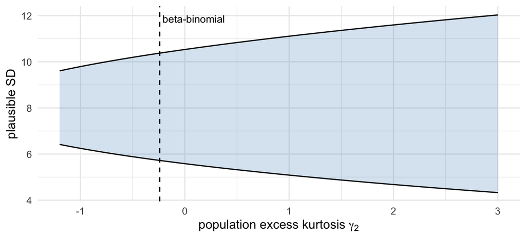

Figure 3: The 0.1% plausibility interval for the SD (N = 50, M = 25 on 0–63, σ fixed at 8) when γ₂ departs from the beta-binomial’s value. The two-moment method takes σ and γ₂ directly. Excess kurtosis widens the interval; a flatter distribution narrows it.

```r
cu <- strait:::.cumulants_from_pmf(strait:::.bb_pmf(63, 25 / 63, 0.052))
g2s <- seq(-1.2, 3, by = 0.1)
kb <- do.call(rbind, lapply(g2s, function(g2) {
  sc <- strait:::.s2_cumulants(modifyList(cu, list(g2 = g2)), 50)
  nu <- 2 * sc$k1^2 / sc$k2
  data.frame(g2 = g2,
             lower = sqrt(sc$k1 * qchisq(0.001, nu) / nu),
             upper = sqrt(sc$k1 * qchisq(0.999, nu) / nu))
}))
ggplot(kb, aes(g2)) +
  geom_ribbon(aes(ymin = lower, ymax = upper), alpha = 0.2, fill = "#2c7fb8") +
  geom_line(aes(y = lower)) + geom_line(aes(y = upper)) +
  geom_vline(xintercept = cu$g2, linetype = 2) +
  annotate("text", x = cu$g2, y = max(kb$upper), label = " beta-binomial",
           hjust = 0, vjust = 1, size = 3.5) +
  labs(x = expression("population excess kurtosis " * gamma[2]),
       y = "plausible SD")
```

# Estimating ρ from a corpus

`rho_corpus_fit()` needs only summary statistics: one row per study with $(L, U, M, SD, N)$. It computes each study’s $(\hat\mu_i, \hat\rho_i, \operatorname{Var}(\hat\rho_i))$ and fits a random-effects meta-regression of $\hat\rho_i$ on a natural spline in $\hat\mu_i$ with `metafor::rma()` (Viechtbauer, 2010). $\operatorname{Var}(\hat\rho_i)$ depends on the kurtosis at $(\mu_i, \rho_i)$. It is first evaluated at $\max(0, \hat\rho_i)$, then once more at the fitted curve, and the model is refitted. The second pass matters because a noisy $\hat\rho_i$ gives a noisy weight.

The corpus below is **simulated**. It has 150 studies on a 0–63 scale with a true $\rho(\mu)$ that rises towards the floor, as depression scales do, between-study SD $\tau = 0.015$, and sample SDs drawn from the model.

```r
set.seed(11)
true_rho <- function(mu) 0.03 + 0.06 * exp(-8 * mu)
k <- 150
mu_i <- runif(k, 0.08, 0.7)
N_i <- sample(30:400, k, replace = TRUE)
rho_i <- pmax(0, true_rho(mu_i) + rnorm(k, 0, 0.015))
SD_i <- vapply(seq_len(k), function(i) {
  pr <- strait:::.bb_pmf(63, mu_i[i], rho_i[i])
  x <- sample(0:63, N_i[i], replace = TRUE, prob = pr)
  sd(x)
}, 0)
corpus <- data.frame(L = 0, U = 63, M = 63 * mu_i, SD = SD_i, N = N_i)
fit <- rho_corpus_fit(corpus)
fit
```

```
#> Corpus meta-regression of rho on mu (150 studies, natural spline df = 3)
#>   tau (between-study SD of rho): 0.0149
```

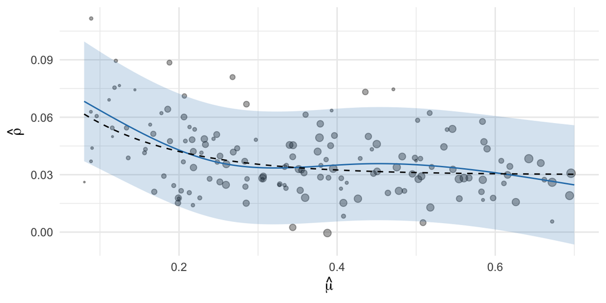

Figure 4: Simulated corpus: per-study method-of-moments ρ̂ (point size ∝ weight), the fitted spline with its prediction band (±1.96 τ_total), and the true curve (dashed).

```r
grid_mu <- seq(0.08, 0.7, length.out = 100)
pr <- predict(fit, grid_mu)
ggplot() +
  geom_point(data = fit$data, aes(mu_hat, rho_hat, size = 1 / var_rho),
             alpha = 0.35, show.legend = FALSE) +
  geom_ribbon(data = pr, aes(mu, ymin = rho - 1.96 * tau_total,
                             ymax = rho + 1.96 * tau_total),
              alpha = 0.2, fill = "#2c7fb8") +
  geom_line(data = pr, aes(mu, rho), colour = "#2c7fb8") +
  geom_line(aes(grid_mu, true_rho(grid_mu)), linetype = 2) +
  scale_size_area(max_size = 3) +
  labs(x = expression(hat(mu)), y = expression(hat(rho)))
```

The corpus prediction then feeds `sd_plausibility()`. Here is the check for the example report (M = 25, SD = 8, N = 50):

```r
p25 <- predict(fit, 25 / 63)
p25
```

```
#> # A tibble: 1 x 5
#>      mu    rho      se    tau tau_total
#>   <dbl>  <dbl>   <dbl>  <dbl>     <dbl>
#> 1 0.397 0.0349 0.00209 0.0149    0.0150
```

```r
sd_plausibility(0, 63, M = 25, N = 50, p = c(0.01, 0.001),
                rho = p25$rho, tau = p25$tau_total,
                condition_on_mean = TRUE)[
  , c("p", "rho", "tau", "sigma", "lower", "upper")]
```

```
#> # A tibble: 2 x 6
#>       p    rho    tau sigma lower upper
#>   <dbl>  <dbl>  <dbl> <dbl> <dbl> <dbl>
#> 1 0.01  0.0349 0.0150  6.91  4.16  9.61
#> 2 0.001 0.0349 0.0150  6.91  3.62 10.5
```

# Recommendations

- Condition on the reported mean (`condition_on_mean = TRUE`). This matters more than the choice of approximation whenever the score distribution is skewed.
- For $N \le 20$ on scales of this length, use `method = "exact"`. It is exact, conditions on the reported mean at its reported precision (`digits`), and costs seconds to a minute.
- Above that, use `method = "chisq2"` with `condition_on_mean = TRUE`. Its upper bound is reliable. Treat its lower bound with caution at moderate $N$. For skewed distributions ($\mu$ near 0 or 1) it runs too low, which is conservative for flagging a small SD. For symmetric, strongly dispersed ones ($\mu = 0.5$, $\rho = 0.15$) it runs too high, which is not.
- A three-moment conditional approximation would need the conditional third cumulant of $S^2$. That derivation is the natural next step, and it could be validated with a faster exact DP (for example, in C++) at $N = 50$.
- Take $\rho$ and $\tau$ from a corpus, pass `tau_total`, and never set $\rho$ from the SD being checked.
- Report the bounds as plausible *under the beta-binomial*, and treat a report outside them as a prompt for a closer look, not as a verdict.

# Function reference

| Function | Purpose |
| --- | --- |
| `sd_plausibility(L, U, M, N, p, rho, tau, sd, method, condition_on_mean, digits, K)` | Plausibility bounds, with hard bounds, clipping and notes. Vectorised over `M`, `N`, `rho`, `tau`, `sd` (recycled together) and `p` (crossed). |
| `s2_exact(m, mu, rho, N, sums)` | Exact distribution of $S^2$ by dynamic programming, optionally conditional on the sum. |
| `bb_cumulants(m, mu, rho)` | Mean, cumulants $\kappa_2$–$\kappa_6$, $\gamma_1$ and $\gamma_2$ from the pmf. |
| `rho_from_summary(L, U, M, SD, N)` | Method-of-moments $\hat\mu$, $\hat\rho$ and $\operatorname{Var}(\hat\rho)$. |
| `rho_corpus_fit(corpus, df)` / `predict(fit, mu)` | Corpus meta-regression of $\hat\rho$ on $\hat\mu$; predicted $\rho$, SE, $\tau$ and $\tau_{\text{total}}$. |

Edge cases: a mean at a scale limit returns zero bounds with a note. A mean outside the scale, $N < 2$, or a missing input returns `NA` with a note. $\rho < 0$ (under-dispersed) is computed at the binomial, with a note. $\rho \ge 1$ uses the endpoint-only limit. `U - L` must be a whole number, so a mean-scored scale must be converted to sum scores first.

# References

Bhatia, R., & Davis, C. (2000). A better bound on the variance. *The American Mathematical Monthly, 107*(4), 353–357.

Box, G. E. P. (1954). Some theorems on quadratic forms applied in the study of analysis of variance problems, I. *The Annals of Mathematical Statistics, 25*(2), 290–302.

Mestdagh, M., Pe, M., Pestman, W., Verdonck, S., Kuppens, P., & Tuerlinckx, F. (2018). Sidelining the mean: The relative variability index as a generic mean-corrected variability measure for bounded variables. *Psychological Methods, 23*(4), 690–707.

Muilwijk, J. (1966). Note on a theorem of M. N. Murthy and V. K. Sethi. *Sankhyā, Series B, 28*, 183.

Satterthwaite, F. E. (1946). An approximate distribution of estimates of variance components. *Biometrics Bulletin, 2*(6), 110–114.

Viechtbauer, W. (2010). Conducting meta-analyses in R with the metafor package. *Journal of Statistical Software, 36*(3), 1–48.